# Generating raster interpretations with digital soil maps: an example with the soil vulnerability index (SVI) in the Dillon and Hall Creek Watersheds

Stephen Roecker

2019-05-03

# 1 Introduction

Digital soil maps (DSM) open up the possibility of generating new raster-based interpretations (RBI) with more spatially explicit soil information. Recently Libohova et al. (2018) generated a DSM of soil hydraulic conductivity (Ksat) and several other soil properties for the Dillon and Hall Creek Watersheds in Southern Indiana. This dataset represents an opportunity to test the development of RBIs. One interpretation that currently has drawn significant interest by USDA-NRCS is the soil vulnerability index (SVI)(USDA-NRCS, 2012; Chan et al., 2017) which is excepted to be incorporated into the Conservation Assessment and Ranking Tool (CART). The SVI is a simple interpretation that uses slope, hydrologic soil groups (which incorporate Ksat, water table depth, and restriction depth) and the K-factor to rank soils potential for runoff or leaching of contaminants.

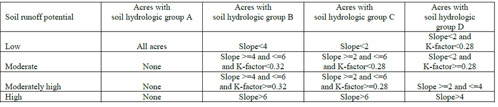

SVI Criteria

For comparison the SVI interp was calculated from a combination of 3 sources: SSURGO, SSURGO + DEM, and a SoLIM + SSURGO + DEM.

# 2 Methods

```r
library(soilDB)
library(dplyr)
library(ggplot2)
library(gdalUtils)
library(raster)
library(sf)
library(tmap)
library(velox)

pp <- "M:/geodata/project_data/Indiana_DSM_Project"
setwd(pp)
```

## 2.2 Import vector-based SSURGO data

The SSURGO tabular data was accessed from Soil Data Access (SDA) and joined to the spatial data (i.e. MUPOLYGON layer) accessed from Web Soil Survey (WSS).

```r
co <- fetchSDA_component(WHERE = "areasymbol IN ('IN037', 'IN117')", duplicates = TRUE)

vars <- c("nationalmusym", "mukey", "cokey", "compname", "comppct_r", "slope_r", "hydgrp")
s <- aqp:: site(co)[vars]

vars <- c("cokey", "hzdept_r", "kwfact")
h <- aqp::horizons(co)[vars]
h2 <- subset(h, hzdept_r < 1)


# component soil moisture (i.e. water table)
cosm <- get_cosoilmoist_from_SDA(WHERE = "areasymbol IN ('IN037', 'IN117')")

# calculate minimum water table depth
mu_wt <- cosm %>%
  filter(status == "Wet") %>%
  group_by(nationalmusym, compname, comppct_r) %>%
  summarize(wetdept_r = min(dept_r, na.rm = TRUE)) %>%
  group_by(nationalmusym) %>%
  summarize(wetdept_r = round(weighted.mean(wetdept_r, w = comppct_r, na.rm = TRUE)))
```

## 2.3 DEM geoprocressing

```r
gdal_translate(
  src_dataset = "M:/geodata/elevation/ned/ned_30m_conus_slope.tif",
  dst_dataset = "ned_30m_hcr_slope.tif",
  projwin     = c(st_bbox(mupol_svi)[c(1, 4, 3, 2)]),
  of          = "GTiff",
  overwrite   = TRUE
  )
```

## 2.4 Calculate SVI from SSURGO

To calculate the SVI from SSURGO, the soil component information was used, and then aggregated to the map unit level.

```r
# component svi ratings
co_svi <- merge(s, h2, by = "cokey", all.x = TRUE)
co_svi <- within(co_svi, {
  hydgrp = as.character(hydgrp)
  hydgrp = sapply(hydgrp, function(x) {
    if (grepl("/", x)) {
      strsplit(x, "/")[[1]][2]
      } else x})
  svi = NA
  # low
  svi = ifelse(
    (hydgrp == "A") |
    (hydgrp == "B" & slope_r < 4) |
    (hydgrp == "C" & slope_r < 2) |
    (hydgrp == "D" & slope_r < 2 & kwfact < 0.28),
    "low", svi
    )
  # moderate
  svi = ifelse(
    (hydgrp == "B" & (slope_r >= 4 & slope_r <= 6) & kwfact <  0.32) |
    (hydgrp == "C" & (slope_r >= 2 & slope_r <= 6) & kwfact <  0.28) |
    (hydgrp == "D" &  slope_r <  2                 & kwfact >= 0.28),
    "moderate", svi
    )
  # moderately high
  svi = ifelse(
    (hydgrp == "B" & (slope_r >= 4 & slope_r <= 6) & kwfact >= 0.32) |
    (hydgrp == "C" & (slope_r >= 2 & slope_r <= 6) & kwfact >= 0.28) |
    (hydgrp == "D" & (slope_r >= 2 & slope_r <= 4)),
     "moderately high", svi
    )
  # high
  svi = ifelse(
    (hydgrp == "B" &  slope_r >  6) |
    (hydgrp == "C" &  slope_r >  6) |
    (hydgrp == "D" &  slope_r >  4),
    "high", svi
    )
  })


# map unit svi ratings
mu_svi <- co_svi %>%
  group_by(nationalmusym, mukey, cokey, svi) %>%
  summarize(comppct_r = sum(comppct_r, na.rm = TRUE)) %>%
  group_by(nationalmusym, mukey) %>%
  summarize(svi = svi[which.max(comppct_r)]) %>%
  mutate(svi = factor(svi, levels = c("low", "moderate", "moderately high", "high")),
         svi_num = as.numeric(svi),
         MUKEY = as.character(mukey)
         )
mu_prop <- co_svi %>%
  group_by(nationalmusym, mukey) %>%
  summarize(kwfact  = Hmisc::wtd.quantile(kwfact, weights = comppct_r, probs = 0.5),
            slope_r = Hmisc::wtd.quantile(slope_r, weights = comppct_r, probs = 0.5),
            hydgrp = hydgrp[which.max(comppct_r)]
            ) %>%
  within(., {
    hydgrp = factor(hydgrp)
    hydgrp_num = as.numeric(hydgrp)
    })

mu_svi <- left_join(mu_svi, mu_prop, by = c("nationalmusym", "mukey"))
mu_svi$mukey <- NULL
mu_svi <- left_join(mu_svi, mu_wt, by = "nationalmusym") %>%
  arrange(MUKEY)

# View(dplyr::select(mu_svi, wetdept_r, MUKEY))


# import ssurgo mupolygon
# mupol <- read_sf(dsn = "M:/geodata/soils/SSURGO_R11_FY19.gdb", layer = "MUPOLYGON", query = "SELECT * FROM MUPOLYGON WHERE AREASYMBOL IN ('IN037', 'IN117')")
# mupol <- rmapshaper::ms_simplify(mupol, 0.5)
# write_sf(mupol, dsn = "mupolygon.shp", layer = "mupolygon", delete_layer = TRUE)
mupol <- read_sf(dsn = "mupolygon.shp", layer = "mupolygon")

mupol_svi <- merge(mupol, mu_svi, by = "MUKEY", all.x = TRUE)


# create shapefile
write_sf(mupol_svi, dsn = "mupolygon_svi.shp", layer = "mupolygon_svi", delete_layer = TRUE)
```

## 2.5 Calculate SVI from SSURGO + DEM

To calculate the SVI from SSURGO and the DEM, the necessary SSURGO data was rasterized, and then combined with the slope gradient using using raster algebra.

```r
mupol_svi <- read_sf(dsn = "mupolygon_svi.shp", layer = "mupolygon_svi")
slope_r <- raster("ned_30m_hcr_slope.tif")


# rasterize ssurgo properties
# svi
vx_svi <- velox(slope_r)$copy()
vx_svi$rasterize(mupol_svi, field = "svi_num")
vx_svi$write(path = "ssurgo_svi_num_30m.tif", overwrite = TRUE)
# kwfact
vx_svi <- velox(slope_r)$copy()
vx_svi$rasterize(mupol_svi, field = "kwfact")
vx_svi$write(path = "ssurgo_kwfact_30m.tif", overwrite = TRUE)
# hydgrp
vx_svi <- velox(slope_r)$copy()
vx_svi$rasterize(mupol_svi, field = "hydgrp_")
vx_svi$write(path = "ssurgo_hydgrp_num_30m.tif", overwrite = TRUE)


vars <- c("ssurgo_hydgrp_num_30m.tif", "ned_30m_hcr_slope.tif", "ssurgo_kwfact_30m.tif")
rs <- stack(vars)


# calculate svi with map algebra
ssurgo_svi_slope <- calc(rs, fun = function(x) {

  svi = NA
  # low
  svi = ifelse(
    (x[1] == 1) |
      (x[1] == 2 & x[2] < 4) |
      (x[1] == 3 & x[2] < 2) |
      (x[1] == 4 & x[2] < 2 & x[3] < 0.28),
    1, svi
  )
  # moderate
  svi = ifelse(
    (x[1] == 2 & (x[2] >= 4 & x[2] <= 6) & x[3] <  0.32) |
      (x[1] == 3 & (x[2] >= 2 & x[2] <= 6) & x[3] <  0.28) |
      (x[1] == 4 &  x[2] <  2                 & x[3] >= 0.28),
    2, svi
  )
  # moderately high
  svi = ifelse(
    (x[1] == 2 & (x[2] >= 4 & x[2] <= 6) & x[3] >= 0.32) |
      (x[1] == 3 & (x[2] >= 2 & x[2] <= 6) & x[3] >= 0.28) |
      (x[1] == 4 & (x[2] >= 2 & x[2] <= 4)),
    3, svi
  )
  # high
  svi = ifelse(
    (x[1] == 2 &  x[2] >  6) |
      (x[1] == 3 &  x[2] >  6) |
      (x[1] == 4 &  x[2] >  4),
    4, svi
  )
},
filename = "ssurgo_svi_num_slope_30m.tif",
datatype = "INT1U",
progress = "text",
overwrite = TRUE
)
```

## 2.6 Calculate SVI from SoLIM + SSURGO + DEM

To calculate the SVI from the DSMs produced by Libohova et al. (2018), it was first necessary to compute the hydrologic soil groups (HSG). This was accomplished by classifying the SolIM Ksat and paralithic layers with the SSURGO water table depths using raster algebra. Since the Ksat layers did not correspond to the depth intervals specificed in the HSG criteria, it was assumed that the minimum of the first 2 Ksat was comparable to those listed in the HSG criteria. For comparison purposes the SoLIM layers were resampled to 10-meters using the nearest neighborhood method.

```r
# load DSM rasters
path <- file.path(pp, "HUC12_Hall_Creek/SoLIM/Draft3")

# harden solim classes
solim_r <- raster(file.path(path, "hcr_d3_s/w001001.adf"))

# ksat layers
ksat_rs <- stack(paste0(path, "/hcr_ksat_l", 1:3, "/w001001.adf"))
ksat_rs <- calc(ksat_rs, fun = function(x) {
  # convert to micrometers / sec
  x * 2.778
  },
  progress = "text"
  )

# restrictive layer
rl_r <- raster(paste0(path, "/d3ssrvparl/w001001.adf"))

dsm_rs <- stack(solim_r, ksat_rs, rl_r)
names(dsm_rs) <- c("classes", "ksat_l1", "ksat_l2", "ksat_l3", "rl_r")
dsm_rs <- projectRaster(dsm_rs, crs = sp::CRS("+init=epsg:5070"), progress = "text")


# rasterize ssurgo properties
# water table depth
vx_wt <- velox(dsm_rs[[1]])$copy()
vx_wt$rasterize(mupol_svi, field = "wetdept_r")
wt_r <- vx_wt$as.RasterLayer()
wt_r <- calc(wt_r, fun = function(x) {
  x[is.na(x)] = 200
  return(x)
  })
writeRaster(wt_r, filename = "mupol_wt.tif", overwrite = TRUE)

ksat_min_60 <- calc(dsm_rs[[2:3]], fun = function(x) min(x, na.rm = TRUE), progress = "text")
ksat_min_100 <- calc(dsm_rs[[2:4]], fun = function(x) min(x, na.rm = TRUE), progress = "text")

dsm_rs <- stack(dsm_rs, wt_r, ksat_min_60, ksat_min_100)
names(dsm_rs)[6:8] <- c("wt_r", "ksat_min_60", "ksat_min_100")

save(dsm_rs, file = "dsm_rs.RData")
```

```r
load(file = "dsm_rs.RData")

# calculate HSG

hsg_r <- calc(dsm_rs, fun = function(x) {

  ksat_min_60  = x[7]
  ksat_min_100 = x[8]
  rl           = x[5]
  wt           = x[6]

  hsg = NA

  # impermeable layer < 50-cm
  # D
  hsg[rl < 50] = 4

  # impermeable layer 50-100-cm
  # water table < 60-cm
  # A/D
  hsg[(rl > 50 | rl <= 100) &
       wt  < 60             &
       ksat_min_60 >  40] = 5
  # B/D
  hsg[(rl > 50 | rl <= 100) &
       wt  < 60             &
       (ksat_min_60 <= 40 & ksat_min_60 > 10)] = 6
  # C/D
  hsg[(rl > 50 | rl <= 100) &
       wt  < 60             &
       (ksat_min_60 <= 10 & ksat_min_60 > 1)] = 7
  # D
  hsg[(rl > 50 | rl <= 100) &
       wt  < 60             &
       ksat_min_60 <= 1] = 4

  # water table >= 60-cm
  # A
  hsg[(rl > 50 | rl <= 100) &
       wt >= 60             &
       ksat_min_60 >  40] = 1
  # B
  hsg[(rl > 50 | rl <= 100) &
       wt >= 60             &
       (ksat_min_60 <= 40 & ksat_min_60 > 10)] = 2
  # C
  hsg[(rl > 50 | rl <= 100) &
       wt >= 60             &
       (ksat_min_60 <= 10 & ksat_min_60 > 1)] = 3
   # D
  hsg[(rl > 50 | rl <= 100) &
       wt >= 60             &
       ksat_min_60 <= 1] = 4

  # impermeable layer > 100-cm or NA
  # water table < 60-cm
  # A/D
  hsg[(rl > 100 | is.na(rl)) &
       wt   < 60                 &
       ksat_min_100 >  10] = 5
  # B/D
  hsg[(rl > 100 | is.na(rl)) &
       wt   < 60                 &
      (ksat_min_100 <= 10 & ksat_min_100 > 4)] = 6
  # C/D
  hsg[(rl > 100 | is.na(rl)) &
       wt < 60                   &
      (ksat_min_100 <= 4  & ksat_min_100 > 0.4)] = 7
  # D
  hsg[(rl > 100 | is.na(rl)) &
       wt < 60                   &
      ksat_min_100 <= 0.4] = 4

  # water table 60-100-cm
  # A
  hsg[(rl > 100 | is.na(rl)) &
      (wt >= 60 | wt < 100)      &
       ksat_min_60 >  40] = 1
  # B
  hsg[(rl > 100 | is.na(rl)) &
      (wt >= 60 | wt < 100)  &
      (ksat_min_60 <= 40 & ksat_min_60 > 10)] = 2
  # C
  hsg[(rl > 100 | is.na(rl)) &
      (wt >= 60 | wt < 100)  &
      (ksat_min_60 <= 10 & ksat_min_60 > 1)] = 3
  # D
  hsg[(rl > 100 | is.na(rl)) &
      (wt >= 60 | wt < 100)  &
       ksat_min_60 <= 1] = 4

  # water table 60-100-cm
  # A
  hsg[(rl > 100 | is.na(rl)) &
      wt  > 100              &
      ksat_min_100 >  10] = 1
  # B
  hsg[(rl > 100 | is.na(rl)) &
      wt  > 100              &
     (ksat_min_100 <= 10 & ksat_min_100 > 4)] = 2
  # C
  hsg[(rl > 100 | is.na(rl)) &
      wt  > 100              &
     (ksat_min_100 <= 4  & ksat_min_100 > 0.4)] = 3
  # D
  hsg[(rl > 100 | is.na(rl)) &
      wt  > 100              &
      ksat_min_100 <= 0.4] = 4

  return(hsg)

  },
  filename = "solim_hsg_num.tif",
  datatype = "INT1U",
  progress = "text",
  overwrite = TRUE
  )


test = calc(dsm_rs, fun = function(x) {

  rl = x[5]
  wt = x[6]
  test = NA

  test[(rl >= 50 | rl < 100) & wt >= 60] = 1

  return(test)

  })
```

```r
vars <- c("solim_hsg_num.tif", "ned_10m_hcr_slope.tif", "mupol_kwfact.tif")
hsg_r <- raster(vars[1])
rs <- stack(vars[2:3])
rs <- crop(rs, hsg_r)
rs <- resample(rs, hsg_r, method = "ngb")
rs <- stack(hsg_r, rs)

# calculate svi with map algebra
solim_svi_r <- calc(rs, fun = function(x) {

  svi = NA
  # low
  svi = ifelse(
    (x[1] == 1) |
      (x[1] == 2 & x[2] < 4) |
      (x[1] == 3 & x[2] < 2) |
      (x[1] == 4 & x[2] < 2 & x[3] < 0.28),
    1, svi
  )
  # moderate
  svi = ifelse(
    (x[1] == 2 & (x[2] >= 4 & x[2] <= 6) & x[3] <  0.32) |
      (x[1] == 3 & (x[2] >= 2 & x[2] <= 6) & x[3] <  0.28) |
      (x[1] == 4 &  x[2] <  2                 & x[3] >= 0.28),
    2, svi
  )
  # moderately high
  svi = ifelse(
    (x[1] == 2 & (x[2] >= 4 & x[2] <= 6) & x[3] >= 0.32) |
      (x[1] == 3 & (x[2] >= 2 & x[2] <= 6) & x[3] >= 0.28) |
      (x[1] == 4 & (x[2] >= 2 & x[2] <= 4)),
    3, svi
  )
  # high
  svi = ifelse(
    (x[1] == 2 &  x[2] >  6) |
      (x[1] == 3 &  x[2] >  6) |
      (x[1] == 4 &  x[2] >  4),
    4, svi
  )
},
filename = "solim_svi_num_slope.tif",
datatype = "INT1U",
progress = "text",
overwrite = TRUE
)
```

# 3 Results & Discussion

## 3.1 Compare SVI from SSURGO vs SSURGO + DEM

```r
setwd(pp)

# sample ssurgo + dem rasters
vars <- c("ssurgo_svi_num_slope_10m.tif", "ned_10m_hcr_slope.tif")
svi_rs   <- stack(vars)

svi_sf <- read_sf("mupolygon_svi.shp")
svi_sp <- as(svi_sf, "Spatial")

samp_pts  <- sp::spsample(svi_sp, n = 5000, type = "regular")
samp_v <- over(samp_pts, svi_sp)
samp_r <- extract(svi_rs, samp_pts, df = TRUE)
samp   <- cbind(samp_v, samp_r)

idx    <- which(names(samp) %in% c("svi_num", "ssurgo_svi_num_slope_10m"))
names(samp)[idx] <- c("ssurgo_svi", "ssurgo_dem_svi")

samp   <- within(samp, {
  ssurgo_svi = factor(ssurgo_svi, levels = 1:4, labels = c("low", "moderate", "moderately-high", "high"))
  ssurgo_dem_svi = factor(ssurgo_dem_svi, levels = 1:4, labels = c("low", "moderate", "moderately-high", "high"))
  })
```

| ssurgo_svi | ssurgo_dem_svi low | ssurgo_dem_svi moderate | ssurgo_dem_svi moderately-high | ssurgo_dem_svi high |
| --- | --- | --- | --- | --- |
| low | 4 | 0 | 1 | 1 |
| moderate | 0 | 8 | 4 | 1 |
| moderately-high | 2 | 1 | 6 | 4 |
| high | 1 | 1 | 8 | 58 |

```
 Accuracy         Kappa AccuracyLower AccuracyUpper  AccuracyNull
   "0.76"        "0.54"        "0.66"        "0.84"        "0.64"
```

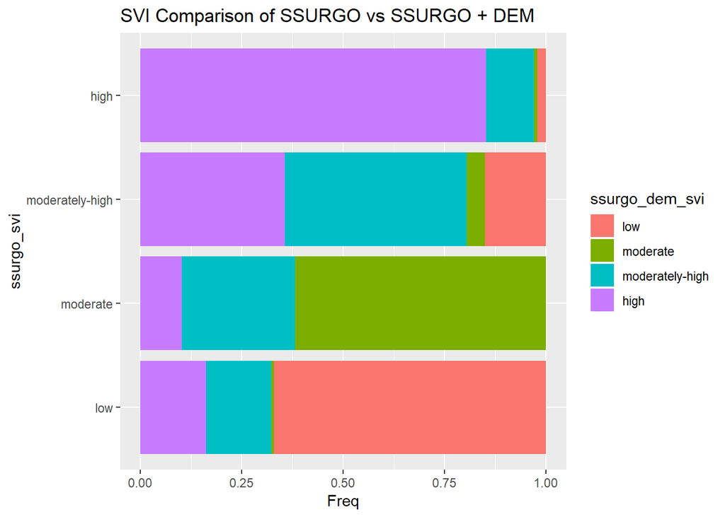

The comparison between the SVI calculated from SSURGO vs SSURGO + DEM showed differences in SVI only due to slope gradient for both Dubios and Orange county. Overall the spatial patterns between the 2 maps appear similar, but the contingency table shows that the moderate and moderately-high SVI SSURGO classes have significant overlap with several SSURGO + DEM classes. The disagreement appears to partially coming from inclusions of ridge-tops and channels within moderately steep map units. In addition within northeast corner of Orange County their is an area of complex low relief where the SVI values differs between the data-sets. Given the narrow range of slope thresholds (e.g. 2-4-6%) used by the SVI, small differences in slope gradient can result in different classes. Also areas of complex low relief are known to be problematic when it comes to estimating slope gradient, which can vary depending on the DEM source and derivative algorithms used to calculate it (Roecker and Thompson, 2010).

## 3.2 Compare SVI from SSURGO vs SoLIM + SSURGO + DEM

```r
setwd(pp)

# sample sssurgo and solim rasters
vars <- c("solim_svi_num_slope.tif", "ssurgo_svi_num_slope_10m.tif")
solim_svi_r  <- raster(vars[1])
ssurgo_svi_r <- raster(vars[2])
solim_svi_r <- resample(solim_svi_r, ssurgo_svi_r, method = "ngb")
svi_rs       <- stack(solim_svi_r, ssurgo_svi_r)

svi_sf <- read_sf("mupolygon_svi.shp")
svi_sp <- as(st_transform(svi_sf, crs = "+init=epsg:5070"), "Spatial")

hcr_sf <- read_sf(file.path(pp, "HUC12_Hall_Creek/watershed_30m.shp"))
hcr_sf <- st_transform(hcr_sf, crs = "+init=epsg:5070")
hcr_sp <- as(hcr_sf, "Spatial")

samp_pts  <- sp::spsample(hcr_sp, n = 5000, type = "regular")

# sample
samp_v <- over(samp_pts, svi_sp)
samp_r  <- extract(svi_rs, samp_pts, df = TRUE)

samp   <- cbind(samp_v, samp_r)
idx    <- which(names(samp) %in% c("svi_num", "solim_svi_num_slope", "ssurgo_svi_num_slope_10m"))
vars <- c("ssurgo_svi", "solim_dem_svi", "ssurgo_dem_svi")
names(samp)[idx] <- vars

samp <- samp[vars]
samp <- within(samp, {
  ssurgo_svi = factor(ssurgo_svi, levels = 1:4, labels = c("low", "moderate", "moderately-high", "high"))
  solim_dem_svi = factor(solim_dem_svi, levels = 1:4, labels = c("low", "moderate", "moderately-high", "high"))
  ssurgo_dem_svi = factor(ssurgo_dem_svi, levels = 1:4, labels = c("low", "moderate", "moderately-high", "high"))
  })
```

| solim_dem_svi | ssurgo_svi low | ssurgo_svi moderate | ssurgo_svi moderately-high | ssurgo_svi high |
| --- | --- | --- | --- | --- |
| low | 1 | 3 | 0 | 1 |
| moderate | 0 | 0 | 1 | 1 |
| moderately-high | 1 | 2 | 5 | 6 |
| high | 2 | 1 | 5 | 71 |

```
##      Accuracy         Kappa AccuracyLower AccuracyUpper  AccuracyNull
##        "0.77"        "0.36"        "0.68"        "0.85"        "0.79"
```

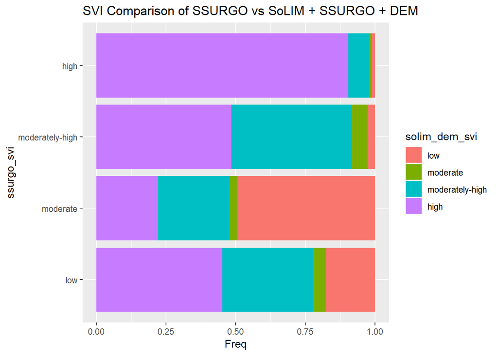

## 3.3 Compare SVI from SSURGO + DEM vs SoLIM + SSURGO + DEM

| solim_dem_svi | ssurgo_dem_svi low | ssurgo_dem_svi moderate | ssurgo_dem_svi moderately-high | ssurgo_dem_svi high |
| --- | --- | --- | --- | --- |
| low | 1 | 3 | 0 | 1 |
| moderate | 0 | 1 | 0 | 0 |
| moderately-high | 1 | 0 | 12 | 1 |
| high | 0 | 0 | 2 | 78 |

```
##      Accuracy         Kappa AccuracyLower AccuracyUpper  AccuracyNull
##        "0.92"        "0.76"        "0.85"        "0.96"         "0.8"
```

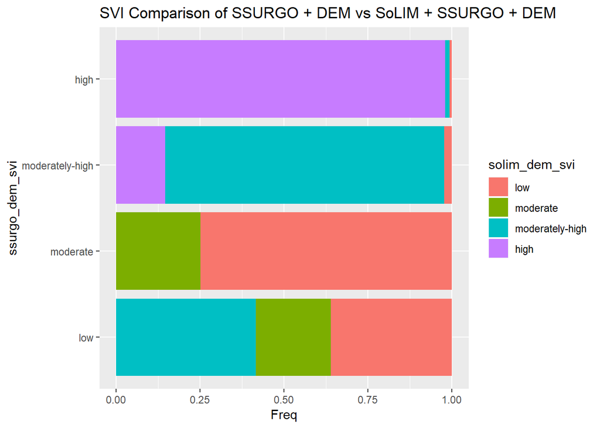

## 3.4 Ksat maps

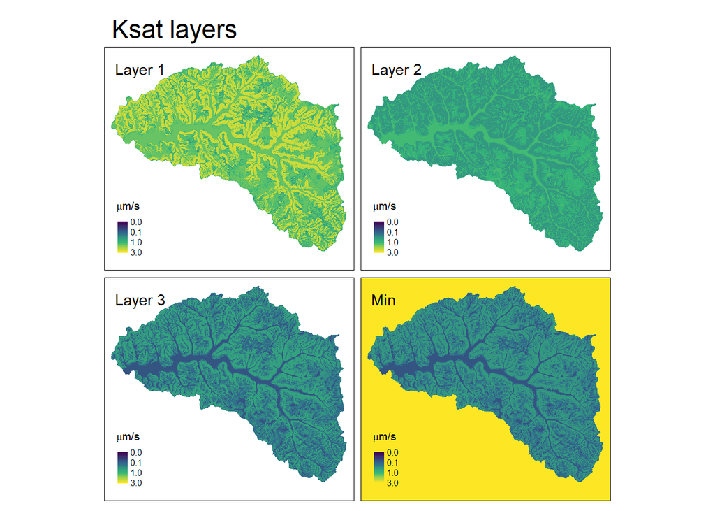

```r
setwd(pp)
load(file = "dsm_rs.RData")

brks <- c(0, 0.1, 1, 3)

tm_shape(dsm_rs[[c(2:4, 8)]]) +
  tm_raster(style = "cont",
            breaks = brks,
            palette = viridis::viridis_pal()(length(brks)),
            title = expression(paste(mu, m, "/", s))
            ) +
  tm_layout(main.title = "Ksat layers",
            legend.position = c("left", "bottom"),
            title = c("Layer 1", "Layer 2", "Layer 3", "Min")
            )
```

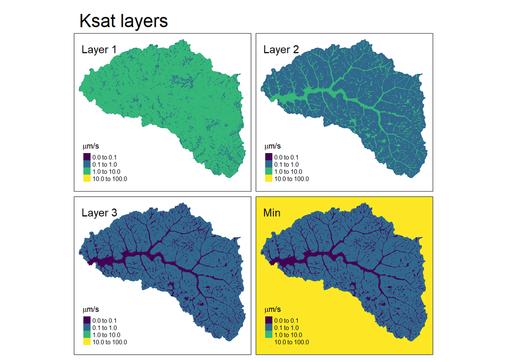

```r
tm_shape(dsm_rs[[c(2:4, 8)]]) +
  tm_raster(breaks = c(0.01, 0.1, 1, 10, 100),
            palette = viridis::viridis_pal()(4),
            title = expression(paste(mu, m, "/", s))
            ) +
  tm_layout(main.title = "Ksat layers",
            legend.position = c("left", "bottom"),
            title = c("Layer 1", "Layer 2", "Layer 3", "Min")
            )
```

## 3.5 SVI maps

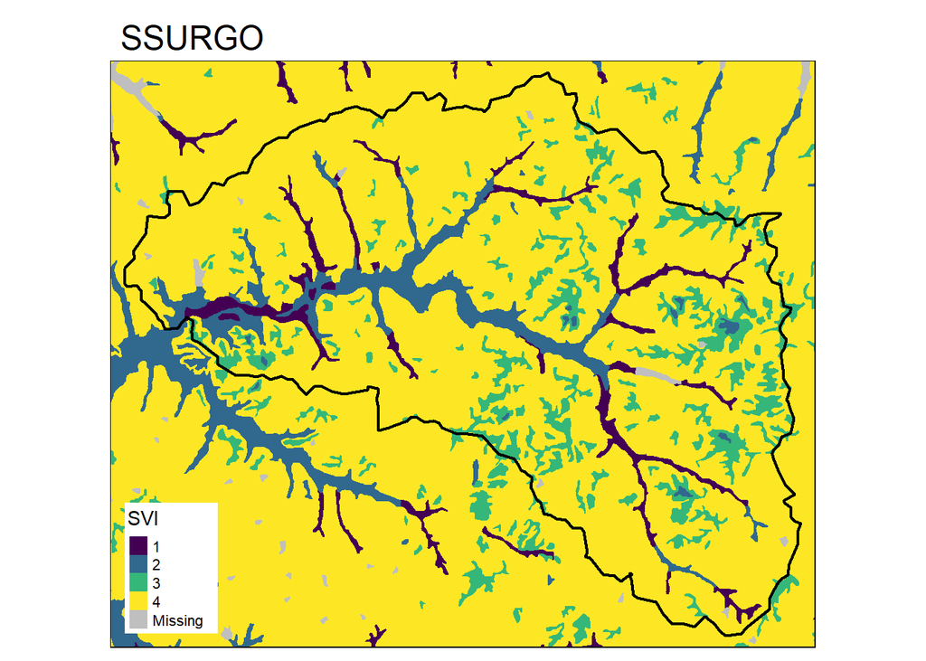

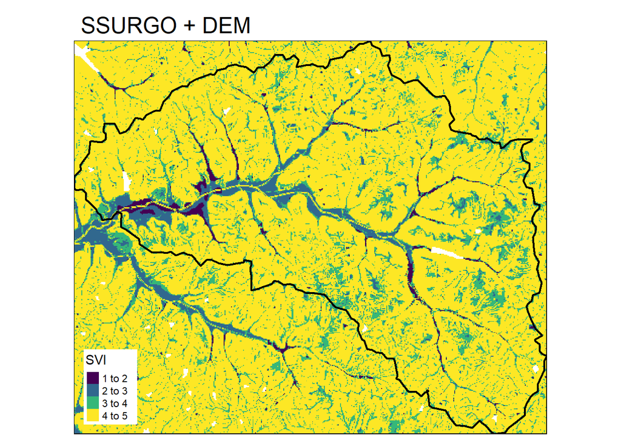

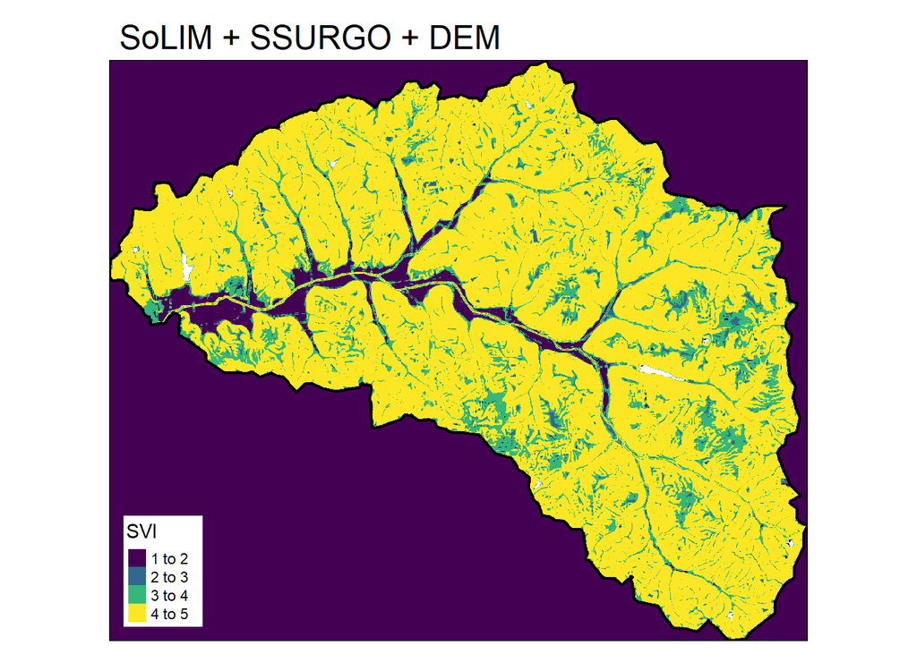

# 4 Conclusions

The comparison between the SVI calculated from SSSURGO vs SSURGO + DEM are similar to results of Chan et al. (2017), although Chan et al. (2017) found less overlap due to greater differences between the SSURGO and NED slope values.

Deriving soil interpretations from DSM represent several challenges. For starters their is a mismatch between the variety of criteria used for soil interpretations and the limited number of soil properties and depth intervals estimated by most DSM. DSM of soil properties typically produce estimates for depth intervals (e.g. 0-5, 5-15, 15-30, 30-60, 60-100, 100-200). To match the depth range criteria of a variety of soil interpretations DSM would either have to produce estimates at 1-cm depth intervals or interpolate between the standard depth intervals with depth splines (e.g. equal area). Computationally it is simpler to derive soil interpretations for a limited range of soil classes, rather than a million pixels. The classes could then be converted to continuous range using the fuzzy mixing of class membership originally demonstrated using SoLIM, if the interpretation rating used a fuzzy ranking.

It would be beneficial if new DSM products considered what was required to generate RBI.

One of primary arguments for DSM is that it produces maps that contain greater spatial detail. The Ksat layer produced by Libohova et al. (2018) do have greater spatial detail, but that detail is over spread over such a narrow range values that it becomes insignificant. This result is similar to the results of the SVI interpretation, where the addition of the spatial detail is overridden when the slope exceeds 6%. The irony is that DSM is presumed to be more feasible in areas of high relief because DEM derivatives explain more soil variation, but most soil interpretations are generally limited on steep slopes. Therefore the more detailed DSM are less informative than they might otherwise be. This may not be the case for hydrologic and conservation models that require soil properties.

# 5 References

Chan, R., Thompson, A. & Sadler, J., 2017. Validating the Soil Vulnerability Index for a claypan watershed. CATENA, 1 1, Volume 148, pp. 185-194.

Horn, B. K. P., 1981. Hill Shading and the Reflectance Map, Proceedings of the IEEE, 69(1):14-47.

Lee, S. et al., 2018. Assessing the suitability of the Soil Vulnerability Index (SVI) on identifying croplands vulnerable to nitrogen loss using the SWAT model. CATENA, 1 8, Volume 167, pp. 1-12.

Libohova, Z. et al., 2018. Soil Systems for Upscaling Saturated Hydraulic Conductivity for Hydrological Modeling in the Critical Zone. Vadose Zone Journal, 30 9, 17(1), p. 20.

USDA-NRCS, 2012. Assessment of the Effects of Conservation Practices on Cultivated Cropland in the Missouri River Basin, s.l.: s.n.